# 326.212 Homework 1

```r
plt <- ggplot(data = diamonds) +
  geom_bar(mapping = aes(x = cut, fill = color, y = ..prop.., group = color))
plt_b <- ggplot_build(plt)
knitr::kable(plt_b$data[[1]])
```

| fill | y | count | prop | x | group | PANEL | ymin | ymax | xmin | xmax | colour | size | linetype | alpha |
| --- | --- | --- | --- | --- | --- | --- | --- | --- | --- | --- | --- | --- | --- | --- |
| #FDE725FF | 0.0423789 | 119 | 0.0423789 | 1 | 7 | 1 | 0.0000000 | 0.0423789 | 0.55 | 1.45 | NA | 0.5 | 1 | NA |
| #8FD744FF | 0.0746548 | 175 | 0.0322759 | 1 | 6 | 1 | 0.0423789 | 0.0746548 | 0.55 | 1.45 | NA | 0.5 | 1 | NA |
| #35B779FF | 0.1111433 | 303 | 0.0364884 | 1 | 5 | 1 | 0.0746548 | 0.1111433 | 0.55 | 1.45 | NA | 0.5 | 1 | NA |
| #21908CFF | 0.1389506 | 314 | 0.0278073 | 1 | 4 | 1 | 0.1111433 | 0.1389506 | 0.55 | 1.45 | NA | 0.5 | 1 | NA |
| #31688EFF | 0.1716481 | 312 | 0.0326975 | 1 | 3 | 1 | 0.1389506 | 0.1716481 | 0.55 | 1.45 | NA | 0.5 | 1 | NA |
| #443A83FF | 0.1945123 | 224 | 0.0228641 | 1 | 2 | 1 | 0.1716481 | 0.1945123 | 0.55 | 1.45 | NA | 0.5 | 1 | NA |
| #440154FF | 0.2185713 | 163 | 0.0240590 | 1 | 1 | 1 | 0.1945123 | 0.2185713 | 0.55 | 1.45 | NA | 0.5 | 1 | NA |
| #FDE725FF | 0.1093305 | 307 | 0.1093305 | 2 | 7 | 1 | 0.0000000 | 0.1093305 | 1.55 | 2.45 | NA | 0.5 | 1 | NA |
| #8FD744FF | 0.2056049 | 522 | 0.0962744 | 2 | 6 | 1 | 0.1093305 | 0.2056049 | 1.55 | 2.45 | NA | 0.5 | 1 | NA |
| #35B779FF | 0.2901425 | 702 | 0.0845376 | 2 | 5 | 1 | 0.2056049 | 0.2901425 | 1.55 | 2.45 | NA | 0.5 | 1 | NA |
| #21908CFF | 0.3672767 | 871 | 0.0771343 | 2 | 4 | 1 | 0.2901425 | 0.3672767 | 1.55 | 2.45 | NA | 0.5 | 1 | NA |
| #31688EFF | 0.4625398 | 909 | 0.0952630 | 2 | 3 | 1 | 0.3672767 | 0.4625398 | 1.55 | 2.45 | NA | 0.5 | 1 | NA |
| #443A83FF | 0.5577730 | 933 | 0.0952332 | 2 | 2 | 1 | 0.4625398 | 0.5577730 | 1.55 | 2.45 | NA | 0.5 | 1 | NA |
| #440154FF | 0.6554852 | 662 | 0.0977122 | 2 | 1 | 1 | 0.5577730 | 0.6554852 | 1.55 | 2.45 | NA | 0.5 | 1 | NA |
| #FDE725FF | 0.2414530 | 678 | 0.2414530 | 3 | 7 | 1 | 0.0000000 | 0.2414530 | 2.55 | 3.45 | NA | 0.5 | 1 | NA |
| #8FD744FF | 0.4635113 | 1204 | 0.2220583 | 3 | 6 | 1 | 0.2414530 | 0.4635113 | 2.55 | 3.45 | NA | 0.5 | 1 | NA |
| #35B779FF | 0.6831645 | 1824 | 0.2196532 | 3 | 5 | 1 | 0.4635113 | 0.6831645 | 2.55 | 3.45 | NA | 0.5 | 1 | NA |
| #21908CFF | 0.8867599 | 2299 | 0.2035955 | 3 | 4 | 1 | 0.6831645 | 0.8867599 | 2.55 | 3.45 | NA | 0.5 | 1 | NA |
| #31688EFF | 1.1135468 | 2164 | 0.2267868 | 3 | 3 | 1 | 0.8867599 | 1.1135468 | 2.55 | 3.45 | NA | 0.5 | 1 | NA |
| #443A83FF | 1.3585197 | 2400 | 0.2449730 | 3 | 2 | 1 | 1.1135468 | 1.3585197 | 2.55 | 3.45 | NA | 0.5 | 1 | NA |
| #440154FF | 1.5818407 | 1513 | 0.2233210 | 3 | 1 | 1 | 1.3585197 | 1.5818407 | 2.55 | 3.45 | NA | 0.5 | 1 | NA |
| #FDE725FF | 0.2877493 | 808 | 0.2877493 | 4 | 7 | 1 | 0.0000000 | 0.2877493 | 3.55 | 4.45 | NA | 0.5 | 1 | NA |
| #8FD744FF | 0.5511207 | 1428 | 0.2633714 | 4 | 6 | 1 | 0.2877493 | 0.5511207 | 3.55 | 4.45 | NA | 0.5 | 1 | NA |
| #35B779FF | 0.8353211 | 2360 | 0.2842004 | 4 | 5 | 1 | 0.5511207 | 0.8353211 | 3.55 | 4.45 | NA | 0.5 | 1 | NA |
| #21908CFF | 1.0942655 | 2924 | 0.2589444 | 4 | 4 | 1 | 0.8353211 | 1.0942655 | 3.55 | 4.45 | NA | 0.5 | 1 | NA |
| #31688EFF | 1.3385539 | 2331 | 0.2442884 | 4 | 3 | 1 | 1.0942655 | 1.3385539 | 3.55 | 4.45 | NA | 0.5 | 1 | NA |
| #443A83FF | 1.5770963 | 2337 | 0.2385424 | 4 | 2 | 1 | 1.3385539 | 1.5770963 | 3.55 | 4.45 | NA | 0.5 | 1 | NA |
| #440154FF | 1.8137015 | 1603 | 0.2366052 | 4 | 1 | 1 | 1.5770963 | 1.8137015 | 3.55 | 4.45 | NA | 0.5 | 1 | NA |
| #FDE725FF | 0.3190883 | 896 | 0.3190883 | 5 | 7 | 1 | 0.0000000 | 0.3190883 | 4.55 | 5.45 | NA | 0.5 | 1 | NA |
| #8FD744FF | 0.7051082 | 2093 | 0.3860199 | 5 | 6 | 1 | 0.3190883 | 0.7051082 | 4.55 | 5.45 | NA | 0.5 | 1 | NA |
| #35B779FF | 1.0802287 | 3115 | 0.3751204 | 5 | 5 | 1 | 0.7051082 | 1.0802287 | 4.55 | 5.45 | NA | 0.5 | 1 | NA |
| #21908CFF | 1.5127473 | 4884 | 0.4325186 | 5 | 4 | 1 | 1.0802287 | 1.5127473 | 4.55 | 5.45 | NA | 0.5 | 1 | NA |
| #31688EFF | 1.9137114 | 3826 | 0.4009642 | 5 | 3 | 1 | 1.5127473 | 1.9137114 | 4.55 | 5.45 | NA | 0.5 | 1 | NA |
| #443A83FF | 2.3120987 | 3903 | 0.3983873 | 5 | 2 | 1 | 1.9137114 | 2.3120987 | 4.55 | 5.45 | NA | 0.5 | 1 | NA |
| #440154FF | 2.7304013 | 2834 | 0.4183026 | 5 | 1 | 1 | 2.3120987 | 2.7304013 | 4.55 | 5.45 | NA | 0.5 | 1 | NA |

실제로 x = 1의 첫 두 row의 count 값과 prop의 비율을 보면, 1번row의 count가 더 작음에도 불구하고 prop이 더 높게 잡힌것이 보인다.

따라서 이러한 문제를 해결하기 위해서는, 그루핑에 따라 문제가 생기는 y = ..prop.. 값을 사용하는것이 아니라, ..count.. 값을 이용하여 다음과 같이 그래프를 그려야만 한다.

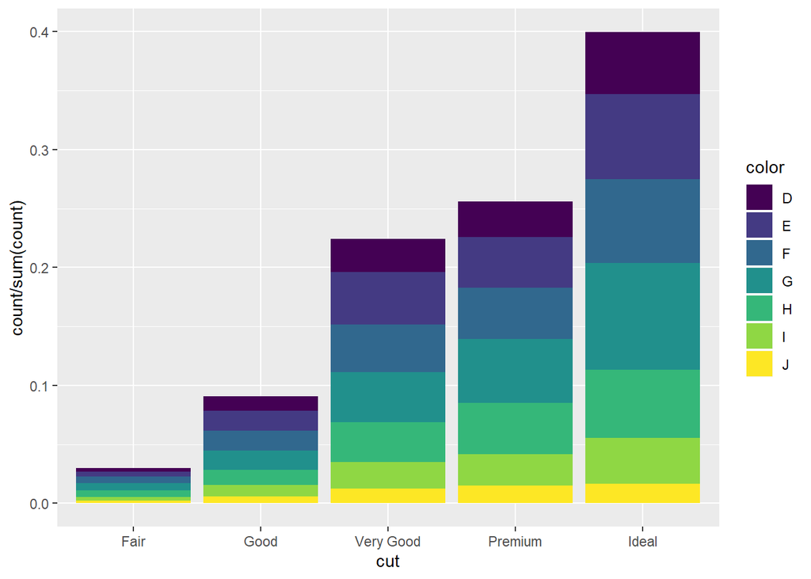

```r
ggplot(data = diamonds) +
  geom_bar(aes(x = cut, y = ..count.. / sum(..count..), fill = color))
```